# Analyzing the Relationship Between State School Performance and Crime Rates

### Rachel Roberts and Shayne Shelton

[**Github Link**](https://sshelton1.github.io/CMPS-3160-Crime-vs-Academics-Project/)

### **Datasets**

[**State Crime Dataset:**](https://think.cs.vt.edu/corgis/csv/state_crime/)

Dataset in CSV format containing crime reports spanning from 1960 to 2019. Data is in rates of reported offenses per 100,000 population and divided into two main categories: property and violent crime. Property crime includes things such as burglary, larceny, and motor related crime. Violent crime refers to assault, murder, rape, and robbery.

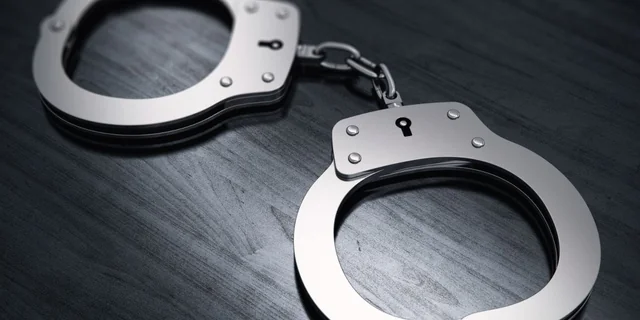

[**State School Performance Data Set:**](https://think.cs.vt.edu/corgis/csv/school_scores/)

Robust dataset in CSV format containing various statistics relating to state school performance from 2005 up until 2015. It contains avergae GPA and SAT scores by state as well as separations by subject and income level. For example, data contains the average GPA of all students in this state during a certain year in Math, or average SAT score for students with a family income between 60-80k.

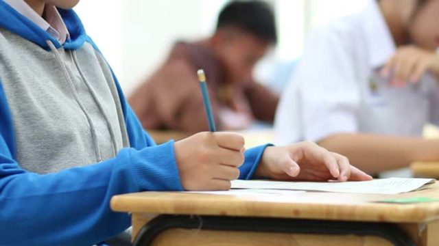

```python
%cd /content
!git clone https://github.com/sshelton1/CMPS-3160-Crime-vs-Academics-Project
```

```
/content
Cloning into 'CMPS-3160-Crime-vs-Academics-Project'...
remote: Enumerating objects: 35, done.
remote: Counting objects: 100% (35/35), done.
remote: Compressing objects: 100% (26/26), done.
remote: Total 35 (delta 8), reused 25 (delta 4), pack-reused 0
Receiving objects: 100% (35/35), 1.01 MiB | 7.63 MiB/s, done.
Resolving deltas: 100% (8/8), done.
```

**Motivation**

The realtionship between education and crime rates is bidirectional. States with poor educational performance may contribute to increasing the crime rate because limited access to quality education can hinder socioeconomic mobility and limit opportunities for future employment, potentially leading individuals to turn to crime as a means of survival. Poor school engagement and high dropout rates can also increase the risk of involvement in criminal activities among disengaged youth. Addressing educational disparities and promoting equitable access to quality education are essential for mitigating these effects and fostering safer, more prosperous communities.

Conversely, higher crime rates in a region can also impact school performance metrics. Higher crime rates can create an environment of fear and instability, leading to decreased attendance and increased dropout rates. Schools in areas with high crime may also struggle to provide a safe and conducive learning environment, which hinders academic achievement. Resources that could be allocated to education may be diverted to address safety concerns which may further compromising the quality of education provided.

Through data science techniques, this notebook explores the relationship betweens state school performance metrics and state crime rates to get a better idea of the underlying patterns and trends related to this complicated issue. We applied statistical methods such as correlation analysis and regression modeling to quantify the strength and direction of relationships between the variables and identify potential predictors of crime rates. These analyses can serve as a starting point for more research into the relationship that can potentially inform policy decisions and interventions aimed at improving education, reducing crime, and improving public safety.

### **Research Questions**

The main research questions we explore in this notebook are:

- Do states with a *higher* average SAT score have *lower* crime rates?
- Is there a statistically significant correlation between these metrics?
- Can crime rates be used to predict SAT scores through a linear regression model, or vice versa?

### **Loading and Parsing Datasets**

We will begin our analysis by loading our datasets into Data Frames and parsing them into a more usable format.

```python
#Mount Drive
from google.colab import drive
drive.mount('/content/drive')
```

```python
#Import necessary libraries
import pandas as pd
import numpy as np
import matplotlib.pyplot as plt
from scipy.stats import pearsonr
```

```python
cd /content/CMPS-3160-Crime-vs-Academics-Project/data
```

```
/content/CMPS-3160-Crime-vs-Academics-Project/data
```

**School Perfomance Scores Dataset**

```python
#Load School Performance Scores data into a Dataframe
school_scores = pd.read_csv('school_scores.csv')
school_scores.head()
```

|  | Year | State.Code | State.Name | Total.Math | Total.Test-takers | Total.Verbal | Academic Subjects.Arts/Music.Average GPA | Academic Subjects.Arts/Music.Average Years | Academic Subjects.English.Average GPA | Academic Subjects.English.Average Years | ... | Score Ranges.Between 600 to 700.Math.Total | Score Ranges.Between 600 to 700.Verbal.Females | Score Ranges.Between 600 to 700.Verbal.Males | Score Ranges.Between 600 to 700.Verbal.Total | Score Ranges.Between 700 to 800.Math.Females | Score Ranges.Between 700 to 800.Math.Males | Score Ranges.Between 700 to 800.Math.Total | Score Ranges.Between 700 to 800.Verbal.Females | Score Ranges.Between 700 to 800.Verbal.Males | Score Ranges.Between 700 to 800.Verbal.Total |
| --- | --- | --- | --- | --- | --- | --- | --- | --- | --- | --- | --- | --- | --- | --- | --- | --- | --- | --- | --- | --- | --- |
| 0 | 2005 | AL | Alabama | 559 | 3985 | 567 | 3.92 | 2.2 | 3.53 | 3.9 | ... | 1096 | 596 | 613 | 1209 | 156 | 292 | 448 | 219 | 250 | 469 |
| 1 | 2005 | AK | Alaska | 519 | 3996 | 523 | 3.76 | 1.9 | 3.35 | 3.9 | ... | 787 | 423 | 375 | 798 | 47 | 116 | 163 | 109 | 115 | 224 |
| 2 | 2005 | AZ | Arizona | 530 | 18184 | 526 | 3.85 | 2.1 | 3.45 | 3.9 | ... | 3814 | 1831 | 1679 | 3510 | 327 | 630 | 957 | 412 | 501 | 913 |
| 3 | 2005 | AR | Arkansas | 552 | 1600 | 563 | 3.90 | 2.2 | 3.61 | 4.0 | ... | 443 | 242 | 226 | 468 | 49 | 83 | 132 | 77 | 93 | 170 |
| 4 | 2005 | CA | California | 522 | 186552 | 504 | 3.76 | 1.8 | 3.32 | 3.8 | ... | 37605 | 16078 | 14966 | 31044 | 5451 | 8792 | 14243 | 5011 | 4766 | 9777 |

5 rows × 99 columns

The Data Frame currently has each variable as a column. In order to make the different variables more easily accessible, we will melt the data frame into tidy format where there is only one observation per row. Each observation will now be able to easily be identified by the State.Name, Year, and Variable name. This allows for much quicker manipulation and filtering for whatever analysis we want to perform.

```python
id_vars = ["Year", "State.Code", "State.Name"] #Set our identifier variables
value_vars = school_scores.columns.difference(id_vars) #Use the remaining columns as varaibles

#Melt the data into tidy format so that each row forms a seperate obervation for a certain state in a certain year
school_scores_tidy = pd.melt(school_scores,
               id_vars=id_vars,
               value_vars=value_vars,
               var_name="Variable",
               value_name="Value")
school_scores_tidy.head()
```

|  | Year | State.Code | State.Name | Variable | Value |
| --- | --- | --- | --- | --- | --- |
| 0 | 2005 | AL | Alabama | Academic Subjects.Arts/Music.Average GPA | 3.92 |
| 1 | 2005 | AK | Alaska | Academic Subjects.Arts/Music.Average GPA | 3.76 |
| 2 | 2005 | AZ | Arizona | Academic Subjects.Arts/Music.Average GPA | 3.85 |
| 3 | 2005 | AR | Arkansas | Academic Subjects.Arts/Music.Average GPA | 3.90 |
| 4 | 2005 | CA | California | Academic Subjects.Arts/Music.Average GPA | 3.76 |

```python
SAT_Verbal = school_scores_tidy[(school_scores_tidy["Variable"] == "Total.Math")]
SAT_Verbal.head()
```

|  | Year | State.Code | State.Name | Variable | Value |
| --- | --- | --- | --- | --- | --- |
| 53661 | 2005 | AL | Alabama | Total.Math | 559.0 |
| 53662 | 2005 | AK | Alaska | Total.Math | 519.0 |
| 53663 | 2005 | AZ | Arizona | Total.Math | 530.0 |
| 53664 | 2005 | AR | Arkansas | Total.Math | 552.0 |
| 53665 | 2005 | CA | California | Total.Math | 522.0 |

**Computing a Sample Statistic**

The new tidy data set allows us to easily compute different metrics across the data. For example, we can calculate what the average GPA in English was for Louisiana was across all years in the data set after some filtering.

```python
#Start by filtering the dataset to only include Values for Louisiana and Average English GPA
state = "LA"
LA_english_GPA = school_scores_tidy[(school_scores_tidy["State.Code"] == state) & (school_scores_tidy["Variable"] == "Academic Subjects.English.Average GPA")]
LA_english_GPA.head()
```

|  | Year | State.Code | State.Name | Variable | Value |
| --- | --- | --- | --- | --- | --- |
| 1172 | 2005 | LA | Louisiana | Academic Subjects.English.Average GPA | 3.46 |
| 1224 | 2006 | LA | Louisiana | Academic Subjects.English.Average GPA | 3.52 |
| 1276 | 2007 | LA | Louisiana | Academic Subjects.English.Average GPA | 3.54 |
| 1329 | 2008 | LA | Louisiana | Academic Subjects.English.Average GPA | 3.53 |
| 1382 | 2009 | LA | Louisiana | Academic Subjects.English.Average GPA | 3.54 |

Now the filteted dataframe only contains average Enligsh GPA values from Lousinina which makes analysis easier. Lets try the computing the mean:

```python
avg_LA_eng_GPA = LA_english_GPA["Value"].mean() #Takes the average of all the values in the filtered data frame
rounded_avg_eng_gpa = round(avg_LA_eng_GPA, 2)
print("Average English GPA for Louisiana:", rounded_avg_eng_gpa)
```

```
Average English GPA for Louisiana: 3.55
```

We can also use the filtered dataset to easily create a basic vizualization.

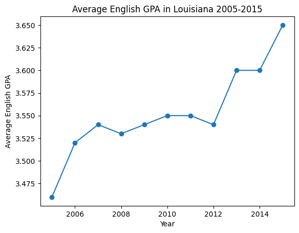

```python
plt.plot(LA_english_GPA['Year'], LA_english_GPA['Value'], marker='o') #Creates a line graph plotting the average Enligsh GPA in Louisiana for each year in the data set
plt.xlabel('Year')
plt.ylabel('Average English GPA')
plt.title('Average English GPA in Louisiana 2005-2015')
```

Now, we will load and parse the state crime dataset in the same way.

**State Crime Dataset**

```python
#Load state crime data into a Dataframe
state_crime = pd.read_csv('state_crime.csv')
state_crime.head()
```

|  | State | Year | Data.Population | Data.Rates.Property.All | Data.Rates.Property.Burglary | Data.Rates.Property.Larceny | Data.Rates.Property.Motor | Data.Rates.Violent.All | Data.Rates.Violent.Assault | Data.Rates.Violent.Murder | ... | Data.Rates.Violent.Robbery | Data.Totals.Property.All | Data.Totals.Property.Burglary | Data.Totals.Property.Larceny | Data.Totals.Property.Motor | Data.Totals.Violent.All | Data.Totals.Violent.Assault | Data.Totals.Violent.Murder | Data.Totals.Violent.Rape | Data.Totals.Violent.Robbery |
| --- | --- | --- | --- | --- | --- | --- | --- | --- | --- | --- | --- | --- | --- | --- | --- | --- | --- | --- | --- | --- | --- |
| 0 | Alabama | 1960 | 3266740 | 1035.4 | 355.9 | 592.1 | 87.3 | 186.6 | 138.1 | 12.4 | ... | 27.5 | 33823 | 11626 | 19344 | 2853 | 6097 | 4512 | 406 | 281 | 898 |
| 1 | Alabama | 1961 | 3302000 | 985.5 | 339.3 | 569.4 | 76.8 | 168.5 | 128.9 | 12.9 | ... | 19.1 | 32541 | 11205 | 18801 | 2535 | 5564 | 4255 | 427 | 252 | 630 |
| 2 | Alabama | 1962 | 3358000 | 1067.0 | 349.1 | 634.5 | 83.4 | 157.3 | 119.0 | 9.4 | ... | 22.5 | 35829 | 11722 | 21306 | 2801 | 5283 | 3995 | 316 | 218 | 754 |
| 3 | Alabama | 1963 | 3347000 | 1150.9 | 376.9 | 683.4 | 90.6 | 182.7 | 142.1 | 10.2 | ... | 24.7 | 38521 | 12614 | 22874 | 3033 | 6115 | 4755 | 340 | 192 | 828 |
| 4 | Alabama | 1964 | 3407000 | 1358.7 | 466.6 | 784.1 | 108.0 | 213.1 | 163.0 | 9.3 | ... | 29.1 | 46290 | 15898 | 26713 | 3679 | 7260 | 5555 | 316 | 397 | 992 |

5 rows × 21 columns

Like we did with the school performance data set, we want our state crime data set to be in a tidy format with one observation per row.

```python
id_vars = ["Year", "State"]  #Set our identifier variables
value_vars1 = state_crime.columns.difference(id_vars)  #Use the remaining columns as varaibles

sc_t = pd.melt(state_crime,
               id_vars=id_vars,
               value_vars=value_vars1,
               var_name="Variable",
               value_name="Value")
sc_t.head()
```

|  | Year | State | Variable | Value |
| --- | --- | --- | --- | --- |
| 0 | 1960 | Alabama | Data.Population | 3266740.0 |
| 1 | 1961 | Alabama | Data.Population | 3302000.0 |
| 2 | 1962 | Alabama | Data.Population | 3358000.0 |
| 3 | 1963 | Alabama | Data.Population | 3347000.0 |
| 4 | 1964 | Alabama | Data.Population | 3407000.0 |

Create a filtered dataframe that only contains the years 2005-2015 since these are the only years we have in the school performance dataset.

```python
# Filter the DataFrame to include only years between 2005 and 2015
sc_t_filtered = sc_t[(sc_t['Year'] >= 2005) & (sc_t['Year'] <= 2015)]

# Print the filtered DataFrame
sc_t_filtered
```

|  | Year | State | Variable | Value |
| --- | --- | --- | --- | --- |
| 45 | 2005 | Alabama | Data.Population | 4548327.0 |
| 46 | 2006 | Alabama | Data.Population | 4599030.0 |
| 47 | 2007 | Alabama | Data.Population | 4627851.0 |
| 48 | 2008 | Alabama | Data.Population | 4661900.0 |
| 49 | 2009 | Alabama | Data.Population | 4708708.0 |
| ... | ... | ... | ... | ... |
| 59176 | 2011 | Wyoming | Data.Totals.Violent.Robbery | 71.0 |
| 59177 | 2012 | Wyoming | Data.Totals.Violent.Robbery | 61.0 |
| 59178 | 2013 | Wyoming | Data.Totals.Violent.Robbery | 75.0 |
| 59179 | 2014 | Wyoming | Data.Totals.Violent.Robbery | 53.0 |
| 59180 | 2015 | Wyoming | Data.Totals.Violent.Robbery | 59.0 |

10868 rows × 4 columns

### **Additional Extraction, Transform, and Load (ETL) + Exploratory Data Analysis (EDA)**

**Average English GPA for each State**

```python
# Filter the DataFrame to include only rows where Variable is 'Academic Subjects.English.Average GPA'
english_gpa_df = school_scores_tidy[school_scores_tidy['Variable'] == 'Academic Subjects.English.Average GPA']

# Pivot the filtered DataFrame to have years as columns and English GPA as values
df_pivot = english_gpa_df.pivot_table(index='State.Name', columns='Year', values='Value', aggfunc='mean')

# Calculate the average GPA for all years for each state, skipping NaN values
df_pivot['Average_GPA_All_Years'] = df_pivot.mean(axis=1, skipna=True)

# Extract only the columns 'State.Name' and 'Average_GPA_All_Years'
average_englishgpa_by_state = df_pivot[['Average_GPA_All_Years']]

# Sort the DataFrame by the average GPA in descending order
average_englishgpa_by_state = average_englishgpa_by_state.sort_values(by='Average_GPA_All_Years', ascending=True)

# Display the DataFrame
average_englishgpa_by_state
```

| Year State.Name | Average_GPA_All_Years |
| --- | --- |
| Virgin Islands | 3.113333 |
| District Of Columbia | 3.129091 |
| Massachusetts | 3.226364 |
| Connecticut | 3.226364 |
| Rhode Island | 3.259091 |
| Maryland | 3.280909 |
| Hawaii | 3.292727 |
| Delaware | 3.295455 |
| New Jersey | 3.310000 |
| New York | 3.318182 |
| New Hampshire | 3.330000 |
| Indiana | 3.331818 |
| Florida | 3.364545 |
| California | 3.371818 |
| Maine | 3.378182 |
| South Carolina | 3.383636 |
| Georgia | 3.392727 |
| Vermont | 3.395455 |
| Virginia | 3.413636 |
| Pennsylvania | 3.415455 |
| Texas | 3.426364 |
| Nevada | 3.431818 |
| Alaska | 3.450909 |
| North Carolina | 3.454545 |
| Arizona | 3.483636 |
| Washington | 3.502727 |
| Idaho | 3.504545 |
| Oregon | 3.506364 |
| Ohio | 3.511818 |
| New Mexico | 3.529091 |
| Montana | 3.551818 |
| Louisiana | 3.552727 |
| Colorado | 3.594545 |
| Alabama | 3.594545 |
| Puerto Rico | 3.605556 |
| Illinois | 3.613636 |
| West Virginia | 3.633333 |
| Tennessee | 3.637273 |
| Missouri | 3.657273 |
| Kansas | 3.676364 |
| Arkansas | 3.680909 |
| Oklahoma | 3.691818 |
| Kentucky | 3.697273 |
| Minnesota | 3.700909 |
| Utah | 3.702727 |
| Mississippi | 3.703636 |
| Michigan | 3.710909 |
| Wisconsin | 3.711818 |
| Nebraska | 3.725455 |
| Wyoming | 3.733636 |
| South Dakota | 3.744545 |
| Iowa | 3.777273 |
| North Dakota | 3.794545 |

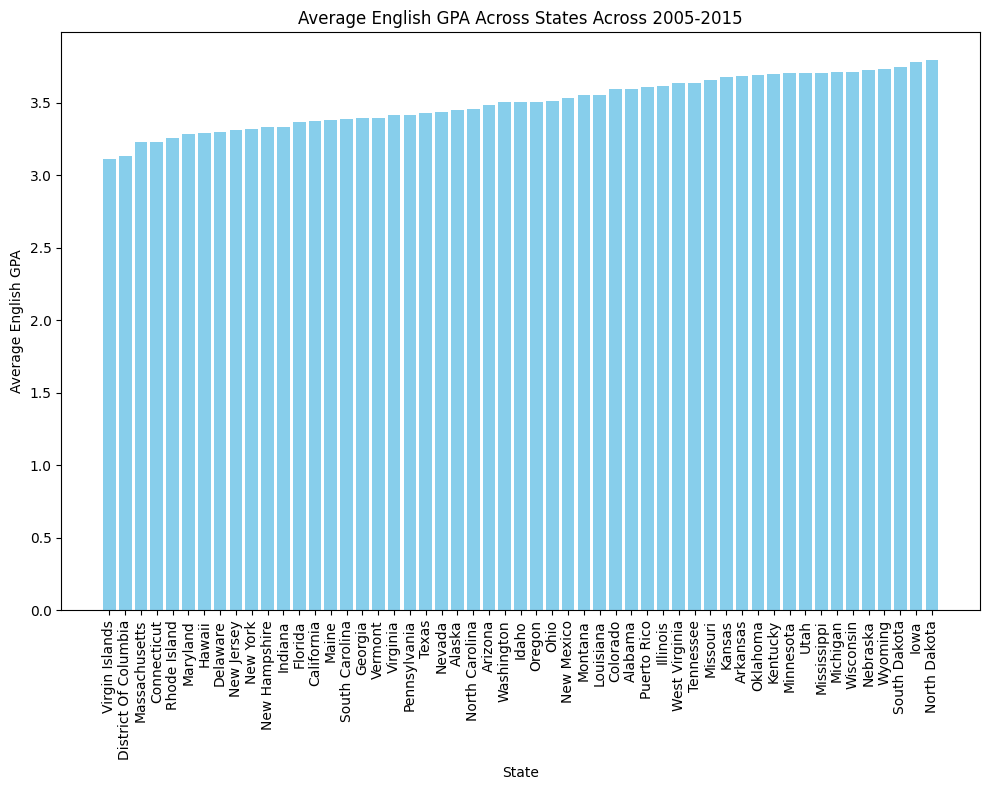

```python
import matplotlib.pyplot as plt

plt.figure(figsize=(10, 8))
plt.bar(average_englishgpa_by_state.index, average_englishgpa_by_state['Average_GPA_All_Years'], color='skyblue')
plt.title('Average English GPA Across States Across 2005-2015')
plt.xlabel('State')
plt.ylabel('Average English GPA')
plt.xticks(rotation=90)

plt.tight_layout()
plt.show()
```

**Average Math GPA for Each State**

```python
# Filter the DataFrame to include only rows where Variable is 'Academic Subjects.Mathematics.Average GPA'
math_gpa_df = school_scores_tidy[school_scores_tidy['Variable'] == 'Academic Subjects.Mathematics.Average GPA']

# Pivot the filtered DataFrame to have years as columns and Math GPA as values
df_pivot = math_gpa_df.pivot_table(index='State.Name', columns='Year', values='Value', aggfunc='mean')

# Calculate the average GPA for all years for each state, skipping NaN values
df_pivot['Average_GPA_All_Years'] = df_pivot.mean(axis=1, skipna=True)

# Extract only the columns 'State.Name' and 'Average_GPA_All_Years'
average_mgpa_by_state = df_pivot[['Average_GPA_All_Years']]

# Sort the DataFrame by the average GPA in descending order
average_mgpa_by_state = average_mgpa_by_state.sort_values(by='Average_GPA_All_Years', ascending=False)

# Display the DataFrame
average_mgpa_by_state
```

| Year State.Name | Average_GPA_All_Years |
| --- | --- |
| North Dakota | 3.643636 |
| South Dakota | 3.623636 |
| Mississippi | 3.618182 |
| Iowa | 3.610000 |
| Wisconsin | 3.577273 |
| Michigan | 3.570000 |
| Kentucky | 3.567273 |
| Nebraska | 3.563636 |
| Minnesota | 3.560000 |
| Oklahoma | 3.550000 |
| Arkansas | 3.549091 |
| Missouri | 3.545455 |
| Wyoming | 3.541818 |
| Kansas | 3.521818 |
| Tennessee | 3.509091 |
| Illinois | 3.501818 |
| Utah | 3.497273 |
| Puerto Rico | 3.444444 |
| Alabama | 3.430909 |
| Louisiana | 3.430000 |
| West Virginia | 3.404444 |
| Colorado | 3.401818 |
| Ohio | 3.381818 |
| New Mexico | 3.337273 |
| Montana | 3.276364 |
| Oregon | 3.262727 |
| Arizona | 3.261818 |
| Idaho | 3.243636 |
| Pennsylvania | 3.240000 |
| Texas | 3.234545 |
| North Carolina | 3.223636 |
| South Carolina | 3.219091 |
| Washington | 3.212727 |
| Maine | 3.210000 |
| Vermont | 3.191818 |
| Georgia | 3.176364 |
| Virginia | 3.173636 |
| New Jersey | 3.160909 |
| Delaware | 3.139091 |
| Alaska | 3.130909 |
| New Hampshire | 3.099091 |
| Massachusetts | 3.098182 |
| Florida | 3.097273 |
| Nevada | 3.088182 |
| Indiana | 3.087273 |
| Connecticut | 3.072727 |
| California | 3.072727 |
| Maryland | 3.055455 |
| Rhode Island | 3.051818 |
| New York | 3.041818 |
| Hawaii | 3.039091 |
| District Of Columbia | 2.973636 |
| Virgin Islands | 2.897778 |

[figure not shown]

```python
plt.figure(figsize=(10, 8))
plt.bar(average_mgpa_by_state.index, average_mgpa_by_state['Average_GPA_All_Years'], color='salmon')
plt.title('Average Mathematics GPA Across States Across 2006-2015')
plt.xlabel('State')
plt.ylabel('Average Mathematics GPA')
plt.xticks(rotation=90)
plt.tight_layout()
plt.show()
```

**Average Crime Rates By State 2005-2015**

Next, to get more insight into the trends in the state crime data set, we will average the rates of property and violent crime across the years 2005-2015. Rates are the number of reported offenses per 100,000 population.

```python
# Filter the DataFrame for years 2005-2015 and 'Data.Rates.Property.All' variable
filtered_df = sc_t[(sc_t['Year'] >= 2005) & (sc_t['Year'] <= 2015) & (sc_t['Variable'] == 'Data.Rates.Property.All')]

average_prates_by_state = filtered_df.groupby('State')['Value'].mean()

average_prates_by_state = average_prates_by_state.sort_values(ascending=False)

average_prates_by_state
```

```
State
District of Columbia    4817.854545
South Carolina          3919.545455
Washington              3886.363636
Arizona                 3825.918182
Louisiana               3724.418182
New Mexico              3715.927273
Arkansas                3710.227273
Texas                   3658.836364
Tennessee               3651.145455
Georgia                 3629.654545
Hawaii                  3625.700000
Alabama                 3620.636364
Florida                 3613.527273
North Carolina          3549.872727
Oklahoma                3423.645455
Missouri                3409.127273
Oregon                  3307.863636
Delaware                3262.381818
Kansas                  3240.863636
Utah                    3228.118182
Ohio                    3226.454545
Nevada                  3177.127273
Indiana                 3100.290909
Maryland                3024.709091
Alaska                  3010.618182
United States           2984.972727
Mississippi             2975.927273
Colorado                2886.809091
Nebraska                2832.254545
California              2809.863636
Montana                 2669.881818
Minnesota               2668.036364
Michigan                2660.581818
Illinois                2639.200000
Rhode Island            2520.045455
Kentucky                2500.781818
Wyoming                 2495.590909
Wisconsin               2488.336364
Iowa                    2390.800000
Maine                   2356.936364
West Virginia           2337.618182
Virginia                2294.136364
Connecticut             2242.063636
Vermont                 2210.509091
Massachusetts           2202.972727
Pennsylvania            2201.263636
New Hampshire           2099.072727
Idaho                   2091.600000
New Jersey              2065.245455
North Dakota            2017.863636
New York                1910.336364
South Dakota            1842.145455
Name: Value, dtype: float64
```

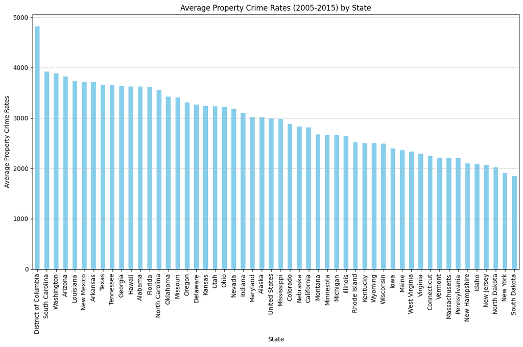

```python
# Plotting
plt.figure(figsize=(12, 8))
average_prates_by_state.plot(kind='bar', color='skyblue')
plt.title('Average Property Crime Rates (2005-2015) by State')
plt.xlabel('State')
plt.ylabel('Average Property Crime Rates')
plt.xticks(rotation=90)
plt.grid(axis='y', linestyle='--', alpha=0.7)
plt.tight_layout()
plt.show()
```

```python
# Filter the DataFrame for years 2005-2015 and 'Data.Rates.Property.All' variable
filtered_df = sc_t[(sc_t['Year'] >= 2005) & (sc_t['Year'] <= 2015) & (sc_t['Variable'] == 'Data.Rates.Violent.All')]

average_vrates_by_state = filtered_df.groupby('State')['Value'].mean()

average_vrates_by_state = average_vrates_by_state.sort_values(ascending=False)

average_vrates_by_state
```

```
State
District of Columbia    1334.109091
Tennessee                667.063636
Nevada                   665.436364
Alaska                   647.436364
South Carolina           636.236364
New Mexico               622.600000
Delaware                 600.909091
Louisiana                595.690909
Florida                  587.745455
Maryland                 557.854545
Arkansas                 505.754545
Missouri                 487.063636
Michigan                 486.354545
Oklahoma                 475.054545
Illinois                 460.645455
California               459.954545
Texas                    458.790909
Arizona                  451.636364
Massachusetts            438.818182
Alabama                  435.818182
United States            420.463636
Georgia                  419.036364
New York                 402.681818
North Carolina           396.681818
Kansas                   387.154545
Pennsylvania             374.409091
Indiana                  342.181818
Colorado                 338.363636
Ohio                     321.218182
Washington               314.981818
Montana                  307.981818
New Jersey               307.490909
West Virginia            297.009091
Nebraska                 282.054545
Mississippi              281.972727
Iowa                     279.072727
South Dakota             277.618182
Connecticut              276.363636
Wisconsin                273.409091
Hawaii                   265.318182
Oregon                   261.990909
Minnesota                255.472727
Kentucky                 247.836364
Rhode Island             244.854545
Idaho                    229.663636
Virginia                 228.909091
North Dakota             227.836364
Wyoming                  222.881818
Utah                     220.354545
New Hampshire            174.336364
Vermont                  130.172727
Maine                    121.945455
Name: Value, dtype: float64
```

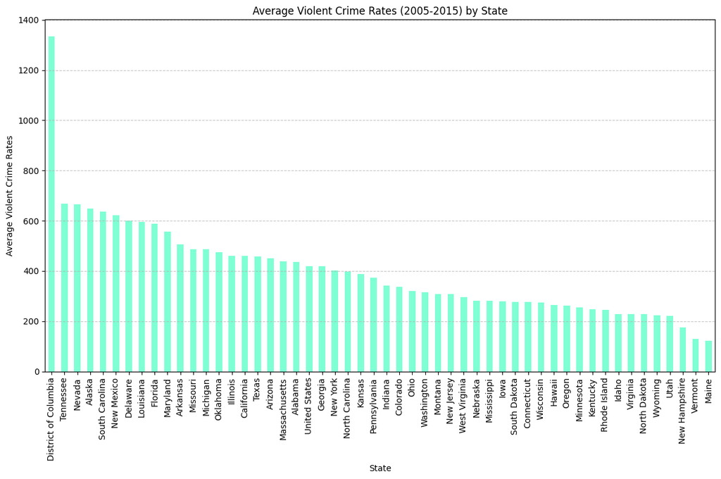

```python
# Plotting
plt.figure(figsize=(12, 8))
average_vrates_by_state.plot(kind='bar', color='aquamarine')
plt.title('Average Violent Crime Rates (2005-2015) by State')
plt.xlabel('State')
plt.ylabel('Average Violent Crime Rates')
plt.xticks(rotation=90)
plt.grid(axis='y', linestyle='--', alpha=0.7)
plt.tight_layout()
plt.show()
```

For these average metrics across states, we will calculate whether there is a statisically signifiant correlation between each subject GPA (math and english) with the different crime rates (violent and property).

Correlation Between Average Mathematics GPA with Violent Crime Rate Across States

```python
# Convert both violent crime rate and property crime rate data series to DataFrames for alignment
average_vrates_df = average_vrates_by_state.reset_index()
average_prates_df = average_prates_by_state.reset_index()

# Merge the data on either 'State' or 'State.Name' column for Math GPA and violent crime rate
merged_data_math_vrates = pd.merge(average_mgpa_by_state, average_vrates_df, left_on='State.Name', right_on='State', how='inner')

# Calculate the Pearson correlation coefficient and p-value for Math GPA and violent crime rate
correlation_coefficient_math_vrates, p_value_math_vrates = pearsonr(merged_data_math_vrates['Average_GPA_All_Years'], merged_data_math_vrates['Value'])

# Print the correlation coefficient and p-value for Math GPA and violent crime rate
print("Pearson correlation coefficient for Math GPA and violent crime rate:", correlation_coefficient_math_vrates)
print("p-value for Math GPA and violent crime rate:", p_value_math_vrates)

# Check if the correlation coefficient is statistically significant (using a significance level of 0.05)
if p_value_math_vrates < 0.05:
    print("There is a statistically significant correlation between average Math GPA and violent crime rate across states.")
else:
    print("There is no statistically significant correlation between average Math GPA and violent crime rate across states.")

# Merge the data on either 'State' or 'State.Name' column for Math GPA and property crime rate
merged_data_math_prates = pd.merge(average_mgpa_by_state, average_prates_df, left_on='State.Name', right_on='State', how='inner')

# Calculate the Pearson correlation coefficient and p-value for Math GPA and property crime rate
correlation_coefficient_math_prates, p_value_math_prates = pearsonr(merged_data_math_prates['Average_GPA_All_Years'], merged_data_math_prates['Value'])

# Print the correlation coefficient and p-value for Math GPA and property crime rate
print("\nPearson correlation coefficient for Math GPA and property crime rate:", correlation_coefficient_math_prates)
print("p-value for Math GPA and property crime rate:", p_value_math_prates)

# Check if the correlation coefficient is statistically significant (using a significance level of 0.05)
if p_value_math_prates < 0.05:
    print("There is a statistically significant correlation between average Math GPA and property crime rate across states.")
else:
    print("There is no statistically significant correlation between average Math GPA and property crime rate across states.")
```

```
Pearson correlation coefficient for Math GPA and violent crime rate: -0.12821256583505453
p-value for Math GPA and violent crime rate: 0.3748962607667073
There is no statistically significant correlation between average Math GPA and violent crime rate across states.

Pearson correlation coefficient for Math GPA and property crime rate: -0.01345233656897091
p-value for Math GPA and property crime rate: 0.9261255298792865
There is no statistically significant correlation between average Math GPA and property crime rate across states.
```

```python
# Convert both data series to DataFrames for alignment
average_prates_df = average_prates_by_state.reset_index()

# Merge the data on either 'State' or 'State.Name' column
merged_data_prates = pd.merge(average_englishgpa_df, average_prates_df, left_on='State.Name', right_on='State', how='inner')

# Calculate the Pearson correlation coefficient and p-value
correlation_coefficient_prates, p_value_prates = pearsonr(merged_data_prates['Average_GPA_All_Years'], merged_data_prates['Value'])

# Print the correlation coefficient and p-value
print("Pearson correlation coefficient for property crime rate:", correlation_coefficient_prates)
print("p-value for property crime rate:", p_value_prates)

# Check if the correlation coefficient is statistically significant (using a significance level of 0.05)
if p_value_prates < 0.05:
    print("There is a statistically significant correlation between average English GPA and property crime rate across states.")
else:
    print("There is no statistically significant correlation between average English GPA and property crime rate across states.")
```

```
Pearson correlation coefficient for property crime rate: 0.008777397335887768
p-value for property crime rate: 0.9517599015182187
There is no statistically significant correlation between average English GPA and property crime rate across states.
```

```python
# Convert both data series to DataFrames for alignment
average_englishgpa_df = average_englishgpa_by_state.reset_index()
average_vrates_df = average_vrates_by_state.reset_index()

# Merge the data on either 'State' or 'State.Name' column
merged_data = pd.merge(average_englishgpa_df, average_vrates_df, left_on='State.Name', right_on='State', how='inner')

# Calculate the Pearson correlation coefficient and p-value
correlation_coefficient, p_value = pearsonr(merged_data['Average_GPA_All_Years'], merged_data['Value'])

# Print the correlation coefficient and p-value
print("Pearson correlation coefficient:", correlation_coefficient)
print("p-value:", p_value)

# Check if the correlation coefficient is statistically significant (using a significance level of 0.05)
if p_value < 0.05:
    print("There is a statistically significant correlation between average English GPA and violent crime rate across states.")
else:
    print("There is no statistically significant correlation between average English GPA and violent crime rate across states.")
```

```
Pearson correlation coefficient: -0.12927683538609766
p-value: 0.3709115491626761
There is no statistically significant correlation between average English GPA and violent crime rate across states.
```

Overall, there is not a strong correlation between the different average subject GPAs with violent or property crime rates. Averaging all the GPAs across all the years in the dataset and doing the same with the state crime dataset might be too broad to pick up on relationships between the data.

We will take a brief detour to analyze Louisiana data specifically.

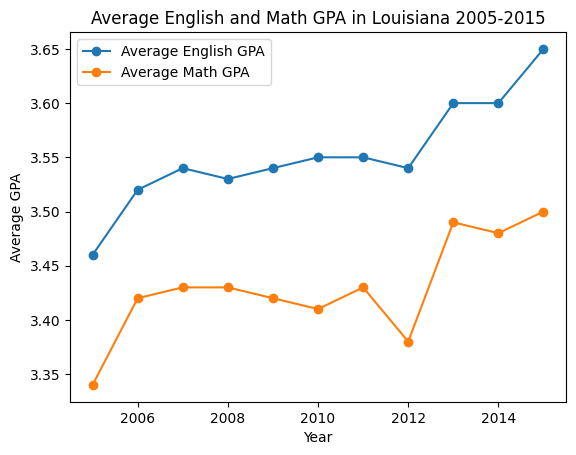

```python
#Start by filtering the dataset to only include Values for Louisiana and Average English GPA
state = "LA"
LA_english_GPA = school_scores_tidy[(school_scores_tidy["State.Code"] == state) & (school_scores_tidy["Variable"] == "Academic Subjects.English.Average GPA")]

plt.plot(LA_english_GPA['Year'], LA_english_GPA['Value'], marker='o', label='Average English GPA') #Creates a line graph plotting the average Enligsh GPA in Louisiana for each year in the data set


LA_math_GPA = school_scores_tidy[(school_scores_tidy["State.Code"] == state) & (school_scores_tidy["Variable"] == "Academic Subjects.Mathematics.Average GPA")]

# Plot Average Math GPA
plt.plot(LA_math_GPA['Year'], LA_math_GPA['Value'], marker='o', label='Average Math GPA')

# Labeling the plot
plt.xlabel('Year')
plt.ylabel('Average GPA')
plt.title('Average English and Math GPA in Louisiana 2005-2015')
plt.legend()  # Show legend with labels for each line

# Show the plot
plt.show()
```

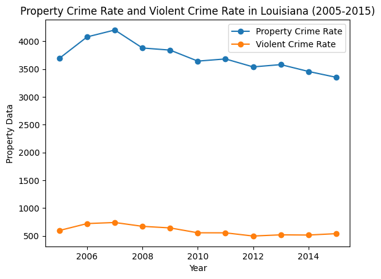

```python
import matplotlib.pyplot as plt

# Define the state as Louisiana
state = 'Louisiana'

# Filter the dataset for Louisiana and Data.Rates.Property.All for years 2005-2015
LA_property_rates = sc_t[(sc_t["State"] == state) &
                         (sc_t["Variable"] == "Data.Rates.Property.All") &
                         (sc_t["Year"] >= 2005) & (sc_t["Year"] <= 2015)]

# Plot Data.Rates.Property.All
plt.plot(LA_property_rates['Year'], LA_property_rates['Value'], marker='o', label='Property Crime Rate')

# Filter the dataset for Louisiana and Data.Rates.Violent.All for years 2005-2015
LA_violent_all = sc_t[(sc_t["State"] == state) &
                          (sc_t["Variable"] == "Data.Rates.Violent.All") &
                          (sc_t["Year"] >= 2005) & (sc_t["Year"] <= 2015)]

# Plot Data.Rates.ViolentAll
plt.plot(LA_violent_all['Year'], LA_violent_all['Value'], marker='o', label='Violent Crime Rate')

# Labeling the plot
plt.xlabel('Year')
plt.ylabel('Property Data')
plt.title('Property Crime Rate and Violent Crime Rate in Louisiana (2005-2015)')
plt.legend()  # Show legend with labels for each line

# Show the plot
plt.show()
```

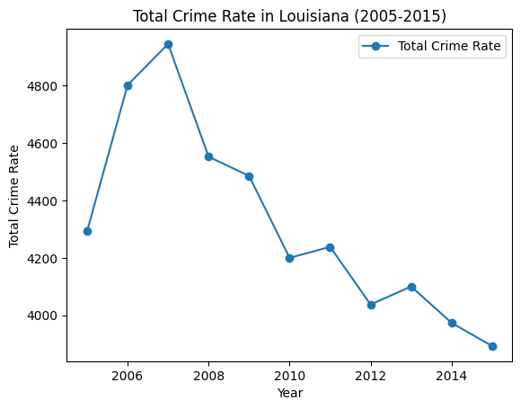

```python
# Calculate total crime rate by summing property and violent crime rates
LA_total_crime_rates = LA_property_rates['Value'].values + LA_violent_all['Value'].values

# Plot Total Crime Rate
plt.plot(LA_property_rates['Year'], LA_total_crime_rates, marker='o', label='Total Crime Rate')

# Labeling the plot
plt.xlabel('Year')
plt.ylabel('Total Crime Rate')
plt.title('Total Crime Rate in Louisiana (2005-2015)')
plt.legend()  # Show legend with labels for each line

# Show the plot
plt.show()
```

## Deailed Analysis and Model Building

For our more detailed analysis, we decided to focus on Verbal and Math SAT scores (Range 200-800).

Differences in curriculum state-to-state and calculation may introduce too many potential confounding variables in state GPA measures, so it is better to use a standardized test. We will again start by looking at the average of all years in the data set.

Average State Math SAT across 2005-2015

```python
# Filter the DataFrame to include only rows where Variable is 'Total.Math'
math_sat_df = school_scores_tidy[school_scores_tidy['Variable'] == 'Total.Math']

# Pivot the filtered DataFrame to have years as columns and Math SAT scores as values
df_pivot_sat = math_sat_df.pivot_table(index='State.Name', columns='Year', values='Value', aggfunc='mean')

# Calculate the average SAT score for all years for each state, skipping NaN values
df_pivot_sat['Average_SAT_All_Years'] = df_pivot_sat.mean(axis=1, skipna=True)

# Extract only the columns 'State.Name' and 'Average_SAT_All_Years'
average_sat_by_state = df_pivot_sat[['Average_SAT_All_Years']]

# Sort the DataFrame by the average SAT score in descending order
average_sat_by_state.sort_values(by='Average_SAT_All_Years', ascending=False)

average_sat_by_state.head()
```

| Year State.Name | Average_SAT_All_Years |
| --- | --- |
| Alabama | 548.909091 |
| Alaska | 516.909091 |
| Arizona | 526.818182 |
| Arkansas | 568.818182 |
| California | 515.818182 |

Average State English SAT across 2005-2015

```python
# Filter the DataFrame to include only rows where Variable is 'Total.Verbal'
verbal_sat_df = school_scores_tidy[school_scores_tidy['Variable'] == 'Total.Verbal']

# Pivot the filtered DataFrame to have years as columns and Verbal SAT scores as values
df_pivot_vsat = verbal_sat_df.pivot_table(index='State.Name', columns='Year', values='Value', aggfunc='mean')

# Calculate the average SAT score for all years for each state, skipping NaN values
df_pivot_vsat['Average_VSAT_All_Years'] = df_pivot_vsat.mean(axis=1, skipna=True)

# Extract only the columns 'State.Name' and 'Average_SAT_All_Years'
average_vsat_by_state = df_pivot_vsat[['Average_VSAT_All_Years']]

# Sort the DataFrame by the average SAT score in descending order
average_vsat_by_state.sort_values(by='Average_VSAT_All_Years', ascending=False)

average_vsat_by_state.head()
```

| Year State.Name | Average_VSAT_All_Years |
| --- | --- |
| Alabama | 554.545455 |
| Alaska | 518.818182 |
| Arizona | 519.727273 |
| Arkansas | 570.636364 |
| California | 499.181818 |

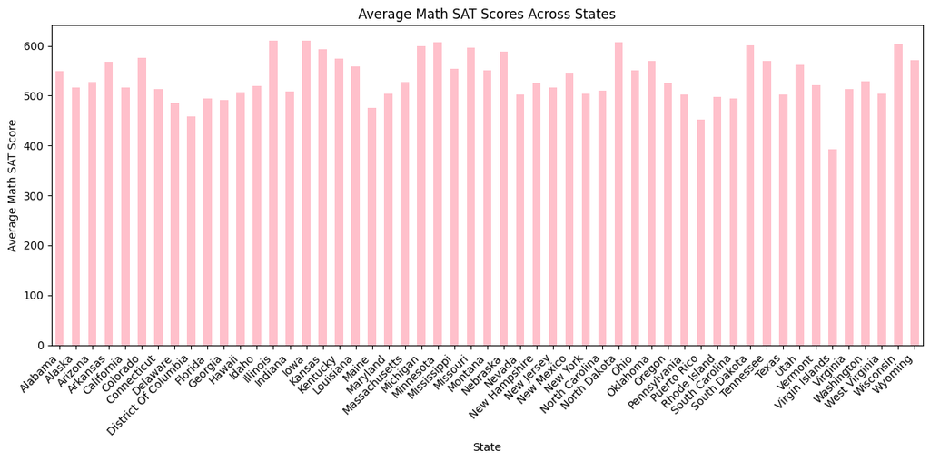

```python
import matplotlib.pyplot as plt

# Create a bar plot
plt.figure(figsize=(12, 6))
average_sat_by_state['Average_SAT_All_Years'].plot(kind='bar', color='pink')

# Add titles and labels
plt.title('Average Math SAT Scores Across States')
plt.xlabel('State')
plt.ylabel('Average Math SAT Score')

# Rotate x-axis labels for better readability
plt.xticks(rotation=45, ha='right')

plt.tight_layout()
plt.show()
```

Instead of doing our correlation analysis on the average across all years in the data set, we will look at the correlation between SAT scores and crime rates for every year and state and consider this in the correlation to give us a more detailed analysis of the trends in the data.

*Filtering Nessecary Datasets for Easier Merging*

```python
sc_t_filtered = sc_t[(sc_t['Year'] >= 2005) & (sc_t['Year'] <= 2015)] #obtain original filtered dataframe
```

```python
SAT_Math = school_scores_tidy[(school_scores_tidy["Variable"] == "Total.Math")] #Obtain data frame with only the Math SAT scores
SAT_Math = SAT_Math.rename(columns={'State.Name': 'State'}) #rename columns for easier merging with state crime dataset
```

```python
SAT_Verbal = school_scores_tidy[(school_scores_tidy["Variable"] == "Total.Verbal")] #Repeat same for Verbal SAT scores
SAT_Verbal= SAT_Verbal.rename(columns={'State.Name': 'State'})
```

### Correlation Between Violent Crime and Math SAT scores

```python
import pandas as pd

# Merge the two DataFrames on 'Year' and 'State'
merged_df = pd.merge(sc_t_filtered, SAT_Math, on=['Year', 'State'], suffixes=('_crime', '_sat'))

# Filter rows where the Variable is 'Data.Totals.Violent.Robbery'
violent_data = merged_df[merged_df['Variable_crime'] == 'Data.Rates.Violent.All']

# Calculate the correlation coefficient
correlation = violent_data['Value_crime'].corr(violent_data['Value_sat'])

# Display the correlation coefficient
print("Correlation coefficient between Violent Crime and Math SAT scores:", correlation)
```

```
Correlation coefficient between Violent Crime and Math SAT scores: -0.1092578620814315
```

```python
from scipy.stats import pearsonr

# Calculate Pearson correlation coefficient and p-value
correlation_coefficient, p_value = pearsonr(violent_data['Value_crime'], violent_data['Value_sat'])

# Check if the p-value is less than the significance level (e.g., 0.05)
significance_level = 0.05
if p_value < significance_level:
    print("The correlation is statistically significant.")
    print("P-value:", p_value)
else:
    print("The correlation is not statistically significant.")
    print("P-value:", p_value)
```

```
The correlation is statistically significant.
P-value: 0.010482676794930321
```

### Correlation Between Property Crime and Math SAT scores

```python
import pandas as pd
from scipy.stats import pearsonr


# Merge the two DataFrames on 'Year' and 'State'
merged_df = pd.merge(sc_t_filtered, SAT_Math, on=['Year', 'State'], suffixes=('_crime', '_sat'))

# Filter rows where the Variable is 'Data.Rates.Property.All'
property_data = merged_df[merged_df['Variable_crime'] == 'Data.Rates.Property.All']

# Calculate the correlation coefficient and p-value
correlation_coefficient, p_value = pearsonr(property_data['Value_crime'], property_data['Value_sat'])

# Check if the p-value is less than the significance level (e.g., 0.05)
significance_level = 0.05
if p_value < significance_level:
    print("The correlation between Property Crime Rates and Math SAT scores is statistically significant.")
else:
    print("The correlation between Property Crime Rates and Math SAT scores is not statistically significant.")

# Print the correlation coefficient and p-value
print("Pearson correlation coefficient:", correlation_coefficient)
print("P-value:", p_value)
```

```
The correlation between Property Crime Rates and Math SAT scores is statistically significant.
Pearson correlation coefficient: -0.09748918336435577
P-value: 0.02246625932822033
```

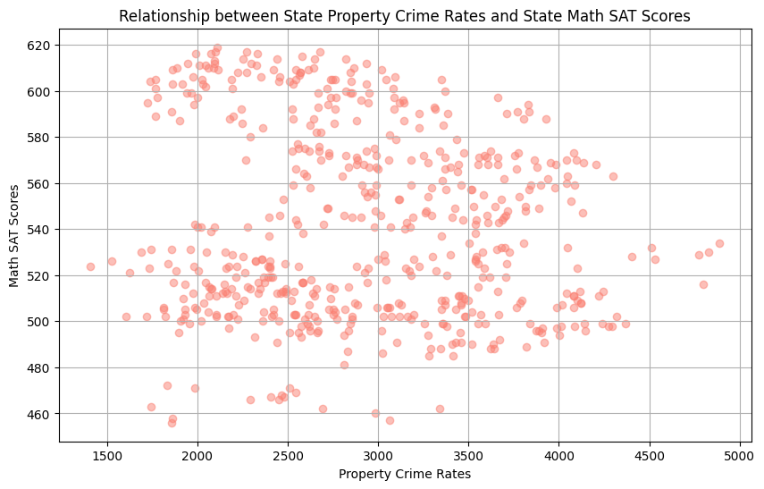

```python
import pandas as pd
import matplotlib.pyplot as plt

# Merge the two DataFrames on 'Year' and 'State'
merged_df = pd.merge(sc_t_filtered, SAT_Math, on=['Year', 'State'], suffixes=('_crime', '_sat'))

# Filter rows where the Variable is 'Data.Rates.Property.All'
property_data = merged_df[merged_df['Variable_crime'] == 'Data.Rates.Property.All']

# Create a scatter plot
plt.figure(figsize=(10, 6))
plt.scatter(property_data['Value_crime'], property_data['Value_sat'], color='salmon', alpha=0.5)
plt.title('Relationship between State Property Crime Rates and State Math SAT Scores')
plt.xlabel('Property Crime Rates')
plt.ylabel('Math SAT Scores')
plt.grid(True)
plt.show()
```

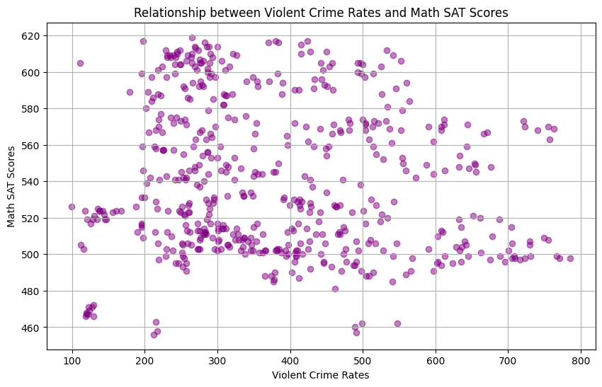

```python
import pandas as pd
import matplotlib.pyplot as plt


# Merge the two DataFrames on 'Year' and 'State'
merged_df = pd.merge(sc_t_filtered, SAT_Math, on=['Year', 'State'], suffixes=('_crime', '_sat'))

# Filter rows where the Variable is 'Data.Rates.Violent.All'
violent_data = merged_df[merged_df['Variable_crime'] == 'Data.Rates.Violent.All']

# Create a scatter plot for violent crime rates and Math SAT scores
plt.figure(figsize=(10, 6))
plt.scatter(violent_data['Value_crime'], violent_data['Value_sat'], color='purple', alpha=0.5)
plt.title('Relationship between Violent Crime Rates and Math SAT Scores')
plt.xlabel('Violent Crime Rates')
plt.ylabel('Math SAT Scores')
plt.grid(True)
plt.show()
```

Visually, correlation doesn’t appear strong, but it is mathematically significant.

### Correlation between Violent Crime Rates and Verbal SAT scores

```python
import pandas as pd

# Merge the two DataFrames on 'Year' and 'State'
merged_df = pd.merge(sc_t_filtered, SAT_Verbal, on=['Year', 'State'], suffixes=('_crime', '_sat'))

# Filter rows where the Variable is 'Data.Totals.Violent.Robbery'
violent_data = merged_df[merged_df['Variable_crime'] == 'Data.Rates.Violent.All']

correlation_coefficient, p_value = pearsonr(violent_data['Value_crime'], violent_data['Value_sat'])

# Check if the p-value is less than the significance level (e.g., 0.05)
significance_level = 0.05
if p_value < significance_level:
    print("The correlation between Violent Crime Rates and Verbal SAT scores is statistically significant.")
else:
    print("The correlation between Violent Crime Rates and Verbal SAT scores is not statistically significant.")

# Print the correlation coefficient and p-value
print("Pearson correlation coefficient:", correlation_coefficient)
print("P-value:", p_value)
```

```
The correlation between Violent Crime Rates and Verbal SAT scores is statistically significant.
Pearson correlation coefficient: -0.09499449343510703
P-value: 0.02616749027117341
```

```python
import pandas as pd
from scipy.stats import pearsonr


# Merge the two DataFrames on 'Year' and 'State'
merged_df = pd.merge(sc_t_filtered, SAT_Verbal, on=['Year', 'State'], suffixes=('_crime', '_sat'))

# Filter rows where the Variable is 'Data.Rates.Property.All'
property_data = merged_df[merged_df['Variable_crime'] == 'Data.Rates.Property.All']

# Calculate the correlation coefficient and p-value
correlation_coefficient, p_value = pearsonr(property_data['Value_crime'], property_data['Value_sat'])

# Check if the p-value is less than the significance level (e.g., 0.05)
significance_level = 0.05
if p_value < significance_level:
    print("The correlation between Property Crime Rates and Verbal SAT scores is statistically significant.")
else:
    print("The correlation between Property Crime Rates and Verbal SAT scores is not statistically significant.")

# Print the correlation coefficient and p-value
print("Pearson correlation coefficient:", correlation_coefficient)
print("P-value:", p_value)
```

```
The correlation between Property Crime Rates and Verbal SAT scores is not statistically significant.
Pearson correlation coefficient: -0.06714393083411004
P-value: 0.11641926666809245
```

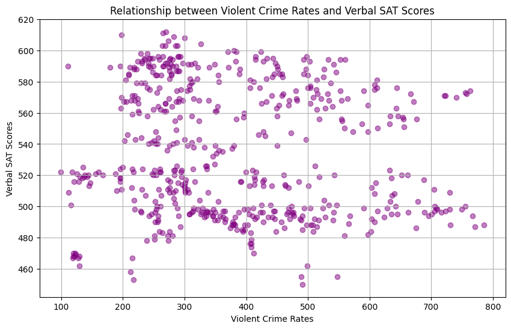

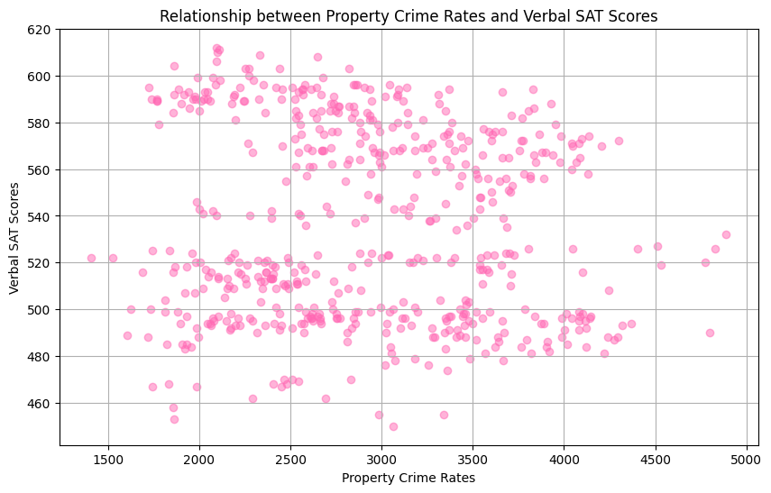

```python
import pandas as pd
import matplotlib.pyplot as plt

# Merge the two DataFrames on 'Year' and 'State'
merged_df = pd.merge(sc_t_filtered, SAT_Verbal, on=['Year', 'State'], suffixes=('_crime', '_sat'))

# Filter rows where the Variable is 'Data.Rates.Violent.All'
violent_data = merged_df[merged_df['Variable_crime'] == 'Data.Rates.Violent.All']

# Filter rows where the Variable is 'Data.Rates.Property.All'
property_data = merged_df[merged_df['Variable_crime'] == 'Data.Rates.Property.All']

# Create scatter plot for 'Data.Rates.Violent.All' and Verbal SAT scores
plt.figure(figsize=(10, 6))
plt.scatter(violent_data['Value_crime'], violent_data['Value_sat'], color='purple', alpha=0.5)
plt.title('Relationship between Violent Crime Rates and Verbal SAT Scores')
plt.xlabel('Violent Crime Rates')
plt.ylabel('Verbal SAT Scores')
plt.grid(True)
plt.show()

# Create scatter plot for 'Data.Rates.Property.All' and Verbal SAT scores
plt.figure(figsize=(10, 6))
plt.scatter(property_data['Value_crime'], property_data['Value_sat'], color='hotpink', alpha=0.5)
plt.title('Relationship between Property Crime Rates and Verbal SAT Scores')
plt.xlabel('Property Crime Rates')
plt.ylabel('Verbal SAT Scores')
plt.grid(True)
plt.show()
```

So, based on our analysis, there is a statistically significant correlation between:

- **Violent** Crime and **Math** SAT scores:
  - Correlation coefficient:* -0.1093
  - P-value: 0.01048
- **Property** Crime and **Math** SAT scores:
  - Correlation coefficient: -0.0975 *P-value:0.02247
- **Violent** Crime and **Verbal** SAT scores:
  - Correlation coefficient: -0.09499 *P-value: 0.0262

Based on this evidence, we hypothesized that using a Linear Regression Model, we will be able to predict SAT scores based on crime rates.

## Linear Regression Modeling

We will begin by using both property and state crime to try and predict SAT scores across the metrics that had a statistically sigifcant correlation.

**Violent crime rates to predict Verbal SAT scores**

```python
import pandas as pd
from sklearn.model_selection import train_test_split
from sklearn.linear_model import LinearRegression
from sklearn.metrics import mean_squared_error, r2_score

# Merge DataFrames on 'Year' and 'State'
merged_df = pd.merge(sc_t_filtered, SAT_Verbal, on=['Year', 'State'], suffixes=('_crime', '_sat'))

# Filter rows where the Variable is 'Data.Rates.Violent.All'
violent_data = merged_df[merged_df['Variable_crime'] == 'Data.Rates.Violent.All']

# Define our independent variable (violent crime rates) and dependent variable (Verbal SAT scores)
X = violent_data[['Value_crime']]
y = violent_data['Value_sat']

# Split the data into our training and testing sets
X_train, X_test, y_train, y_test = train_test_split(X, y, test_size=0.2, random_state=42)

# Create and fit the linear regression model
model = LinearRegression()
model.fit(X_train, y_train)

# Make predictions on the test set
y_pred = model.predict(X_test)

# Calc mean squared error and R-squared
mse = mean_squared_error(y_test, y_pred)
r2 = r2_score(y_test, y_pred)

print("Mean Squared Error:", mse)
print("R-squared:", r2)
```

```
Mean Squared Error: 1570.3583224821539
R-squared: 0.02331744320660878
```

**Violent crime rates to predict Math SAT scores**

```python
import pandas as pd
from sklearn.model_selection import train_test_split
from sklearn.linear_model import LinearRegression
from sklearn.metrics import mean_squared_error, r2_score


# Merge the two DataFrames on 'Year' and 'State'
merged_df = pd.merge(sc_t_filtered, SAT_Math, on=['Year', 'State'], suffixes=('_crime', '_sat'))

# Filter rows where the Variable is 'Data.Rates.Violent.All'
violent_data = merged_df[merged_df['Variable_crime'] == 'Data.Rates.Violent.All']

# Define the independent variable (violent crime rates) and dependent variable (Math SAT scores)
X = violent_data[['Value_crime']]
y = violent_data['Value_sat']

# Split the data into training and testing sets
X_train, X_test, y_train, y_test = train_test_split(X, y, test_size=0.2, random_state=42)

# Create and fit the linear regression model
model = LinearRegression()
model.fit(X_train, y_train)

# Make predictions on the test set
y_pred = model.predict(X_test)

# Calculate mean squared error and R-squared
mse = mean_squared_error(y_test, y_pred)
r2 = r2_score(y_test, y_pred)

print("Mean Squared Error:", mse)
print("R-squared:", r2)
```

```
Mean Squared Error: 1563.1446430586477
R-squared: 0.03226531736360605
```

**Multiple Linear Regression: Violent and Property Crime to Predict Math SAT Scores**

Both our models that used violent crime as a sole predictor had a high Mean Squared Error and a low R-squared, indicating a low accuracy and predicted value. We then attempted to make a multiple linear regression model using both types of crime rates as a predictor for math SAT scores.

```python
import pandas as pd
from sklearn.model_selection import train_test_split
from sklearn.linear_model import LinearRegression
from sklearn.metrics import mean_squared_error, r2_score


# Merge the two DataFrames on 'Year' and 'State'
merged_df = pd.merge(sc_t_filtered, SAT_Math, on=['Year', 'State'], suffixes=('_crime', '_sat'))

# Filter rows where the Variable is 'Data.Rates.Violent.All' and 'Data.Rates.Property.All'
violent_data = merged_df[merged_df['Variable_crime'] == 'Data.Rates.Violent.All']
property_data = merged_df[merged_df['Variable_crime'] == 'Data.Rates.Property.All']

# Combine the two datasets on 'Year' and 'State'
combined_data = pd.merge(violent_data, property_data, on=['Year', 'State'], suffixes=('_violent', '_property'))

# Filter columns based on their names
X_cols = combined_data.filter(like='Value_crime').columns
y_col = combined_data.filter(like='Value_sat').columns[0]  # Assuming there's only one SAT score column

# Define the independent variables (violent crime rate and property crime rate) and dependent variable (Math SAT scores)
X = combined_data[X_cols]
y = combined_data[y_col]

# Split the data into training and testing sets
X_train, X_test, y_train, y_test = train_test_split(X, y, test_size=0.2, random_state=42)

# Create and fit the multiple linear regression model
model = LinearRegression()
model.fit(X_train, y_train)

# Make predictions on the test set
y_pred = model.predict(X_test)

# Calculate mean squared error and R-squared
mse = mean_squared_error(y_test, y_pred)
r2 = r2_score(y_test, y_pred)

print("Mean Squared Error:", mse)
print("R-squared:", r2)
```

```
Mean Squared Error: 1564.9969423935395
R-squared: 0.031118568521802392
```

**Verbal SAT Scores to Predict Violent Crime**

```python
import pandas as pd
from sklearn.model_selection import train_test_split
from sklearn.linear_model import LinearRegression
from sklearn.metrics import mean_squared_error, r2_score

# Merge DataFrames on 'Year' and 'State'
merged_df = pd.merge(sc_t_filtered, SAT_Verbal, on=['Year', 'State'], suffixes=('_crime', '_sat'))

# Filter rows where the Variable is 'Data.Rates.Violent.All'
violent_data = merged_df[merged_df['Variable_crime'] == 'Data.Rates.Violent.All']

# Define our independent variable (Verbal SAT scores) and dependent variable (violent crime rates)
X = violent_data[['Value_sat']]
y = violent_data['Value_crime']

# Split the data into our training and testing sets
X_train, X_test, y_train, y_test = train_test_split(X, y, test_size=0.2, random_state=42)

# Create and fit the linear regression model
model = LinearRegression()
model.fit(X_train, y_train)

# Make predictions on the test set
y_pred = model.predict(X_test)

# Calculate mean squared error and R-squared
mse = mean_squared_error(y_test, y_pred)
r2 = r2_score(y_test, y_pred)

print("Mean Squared Error:", mse)
print("R-squared:", r2)
```

```
Mean Squared Error: 23012.067505107178
R-squared: -0.0031964986166197473
```

**Math SAT Scores to Predict Violent Crime**

```python
import pandas as pd
from sklearn.model_selection import train_test_split
from sklearn.linear_model import LinearRegression
from sklearn.metrics import mean_squared_error, r2_score

# Merge DataFrames on 'Year' and 'State'
merged_df = pd.merge(sc_t_filtered, SAT_Math, on=['Year', 'State'], suffixes=('_crime', '_sat'))

# Filter rows where the Variable is 'Data.Rates.Violent.All'
violent_data = merged_df[merged_df['Variable_crime'] == 'Data.Rates.Violent.All']

# Define our independent variable (Math SAT scores) and dependent variable (violent crime rates)
X = violent_data[['Value_sat']]
y = violent_data['Value_crime']

# Split the data into our training and testing sets
X_train, X_test, y_train, y_test = train_test_split(X, y, test_size=0.2, random_state=42)

# Create and fit the linear regression model
model = LinearRegression()
model.fit(X_train, y_train)

# Make predictions on the test set
y_pred = model.predict(X_test)

# Calculate mean squared error and R-squared
mse = mean_squared_error(y_test, y_pred)
r2 = r2_score(y_test, y_pred)

print("Mean Squared Error:", mse)
print("R-squared:", r2)
```

```
Mean Squared Error: 22796.51092723738
R-squared: 0.00620055378316009
```

# Conclusions and Discussion

Across all of our models, Low R-squared values indicate that only a small proportion of the variability in SAT scores is explained by crime rates alone.

Relatively high MSE values suggest that the models' predictions deviate substantially from actual SAT scores, meaning they have a limited accuracy.

So, we can conclude that There is a statistically significant correlation between:

- State Math SAT scores and State Property and Violent Crime Rates
- State Verbal SAT scores and violent Crime Rates

However, our linear regression and multiple regression models using property and violent crime rates as predictors have limited predictive power for predicting SAT scores, and vice versa. Additional variables beyond crime rates necessary to improve the predictive accuracy of the models.

These conclusions make sense in the context of the real world. We looked at very broad data sets that looked at states as a whole, when there is a lot of variation between school performance and crime rates within different regions of a state. Performing more specific analyses on certain counties within states would likely lead to better predictive models. There are also many outside factors that affect school performance other than crime rates like socioeconomic status and educational resources.

**Further Reading**

If you are interested in reading more on this topic, check out the following articles:

[School Climate and the Impact of Neighborhood Crime on Test Scores](https://www.ncbi.nlm.nih.gov/pmc/articles/PMC6545988/)

[Jayla Nicken's Study of Violent Crime's Impact on SAT Scores](https://afro.com/this-high-school-student-studied-how-violent-crime-impacts-sat-scores-heres-what-she-found/)

[SAT begins measuring "Environmental Context" of Neighborhoods to give insights to hardship that may affect student scores in a certain region](https://www.wavy.com/news/national/sat-to-measure-crime-rate-poverty-level-of-a-students-neighborhood/)